# HW 6

JAYNA CLARK

2025-04-14

```r
library(dplyr)
```

```r
library(tidyr)
library(ggplot2)
```

Import data set

```r
load("house_prices.rda")
```

1. Use facet_wrap to draw line plots to represent the trend for house_price_index over years for each state. . Please have three ticks on the x axis which are for years 1980, 2000, and 2020. Since you have limited space your labels can be ’80, ’00, and ’20 for these ticks.

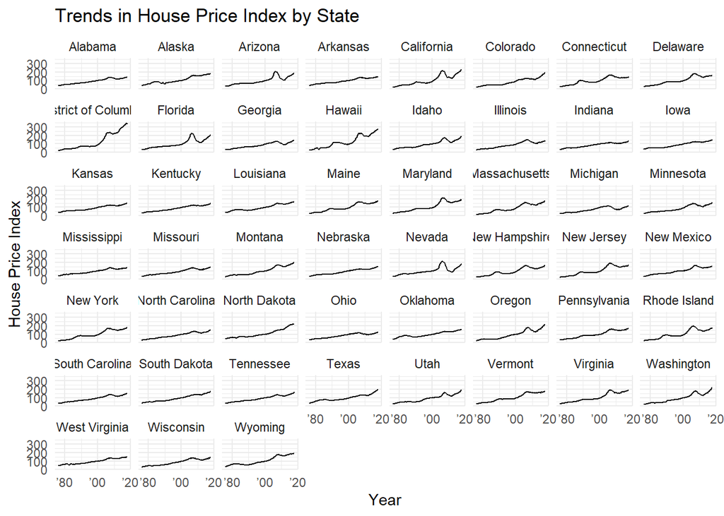

```r
ggplot(house_prices, aes(x = date, y = house_price_index)) +
  geom_line() +
 facet_wrap(~ state)+
  scale_x_continuous(
      breaks = as.Date(c("1980-01-01", "2000-01-01", "2020-01-01")),
    labels = c("’80", "’00", "’20")) +
  labs(
    x = "Year",
    y = "House Price Index",
    title = "Trends in House Price Index by State") +
  theme_minimal()
```

2. Use gather() function from tidyr to reshape your data in a way that it will have measure and value columns for house_price_index and unemploy_perc, respectively, in two columns. You should leave out remaining attributes by using ”-” in front them inside the function. Then, direct the output to a new data frame called house_reshaped Please refer to examples we did in class.

```r
house_reshaped <- house_prices |>
  gather(key = "measure", value = "value", house_price_index, unemploy_perc)
```

3. Use house_reshaped to replicate the graph in 2a with two lines where each represents house_price_index and unemploy_perc over the years for each state. Once you have the chart, please comment on it as to whether it’s a good graph to present those two pieces of information.

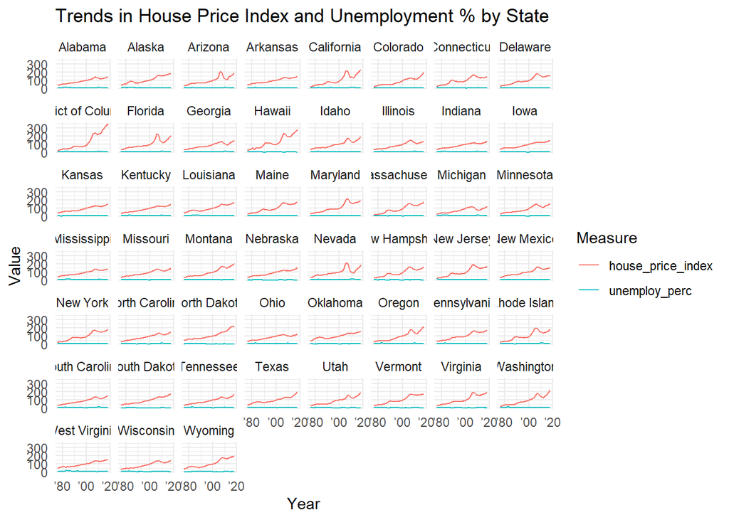

```r
ggplot(house_reshaped, aes(x = date, y = value, color = measure))+
  geom_line() +
  facet_wrap(~state) +
  scale_x_continuous(
    breaks = as.Date(c("1980-01-01", "2000-01-01", "2020-01-01")),
    labels = c("’80", "’00", "’20")) +
  labs(title = "Trends in House Price Index and Unemployment % by State",
       x = "Year",
       y = "Value",
       color = "Measure") +
  theme_minimal()
```

It is a good graph to present House price index- unemployment percent is not shown well as it is much smaller and it is a percentage. It is not shown well because the y-axis goes up to 300 whereas the unemployment % has a maximum value of about 18.